# Random forest script to identify interesting features

Marc Galland

2016-07-04

This script should identify the most important metabolites that explain the phenotype of interest among our tomato accessions.

# 1 Global knitr options & set.seed

```r
knitr::opts_chunk$set(cache=FALSE,warning=FALSE,message=FALSE,fig.align="center")
set.seed(153)
```

# 2 Load libraries

```r
library(reshape2)
library(ggplot2)
library(dplyr)
library(randomForest)
library(combinat)
library(miscTools)
library(yaml)
library(tools)
library(ggrepel)
source("usefulFunctions.R")
```

# 3 Set number of bootstraps (N)

```r
# number of bootstraps
nboots = 500
```

# 4 Import parameters from YAML file

```r
# import YAML file as a list
config = yaml::yaml.load_file("rfconfig.yaml")
```

# 5 import data + bootstraps + calculate stats for each data type.

Data are first imported. Then, we transform the dataframes (wide to long format) to perform median/mean calculations. Finally data are merged and converted to a wide dataframe.

## 5.1 bioassay data import

Based on the type of phenotypic data (e.g. thrips or whitefly) I parse the data differently.

```r
# import data file
if (tools::file_ext(config$phenotype$data) == "csv"){
  phenotype = na.omit(read.csv(config$phenotype$data,stringsAsFactors=F))
} else if (tools::file_ext(config$phenotype$data) == "txt"){
  phenotype = na.omit(read.delim(config$phenotype$data,sep="\t",stringsAsFactors=F))
  }

# depending on the data type, different parsing are done
if (config$phenotype$type == "whitefly"){
  # melt (wide to long format)
  m_phenotype = melt(phenotype[c("accession","cage","percentage")],id.vars = c("accession","cage"),measure.vars = c("percentage"),value.name = "percentage")
  m_phenotype$variable = NULL
  m_phenotype$cage = NULL
  # group and compute value by accession
  by_accession = dplyr::group_by(m_phenotype,accession)
  phenotype = dplyr::summarise(by_accession,value = params$phenotype$stat(percentage))
} else if (config$phenotype$type == "thrips"){
  colnames(phenotype) = c("accession","value")
  }
```

## 5.2 import metabolome data

```r
# import data file
if (tools::file_ext(config$metabolites$data) == "csv"){
  metabolites = na.omit(read.csv(config$metabolites$data,stringsAsFactors=F))
} else if (tools::file_ext(config$metabolites$data) == "txt"){
  metabolites = na.omit(read.delim(config$metabolites$data,sep="\t",stringsAsFactors=F))
  }

# replace wrong names in columns
colnames(metabolites) = gsub(pattern = "^X",replacement = "ion",x = colnames(metabolites))
```

## 5.3 Operations on the metabolite dataframe

1. Average the technical duplicate measurements (one sample measured twice)
2. Divide the data into a training and a test datasets. To do so, I randomly select two measurements per accession for the training set and one for the test set.
3. Average metabolite abundance for each accession for the train and test datasets

```r
# melt metabolite data
m_metabolome = melt(metabolites,id.vars = c("accession","sample"),variable.name = c("compound"))

# creates two lists that will shelter the bootstraps of train / test dfs
trains = list()
tests = list()

# bootstraps
for (k in seq_along(1:nboots)){
  # Creates two empty dataframe to accomodate training and test datasets
  train = data.frame()
  test = data.frame()
  # for each accession and each compound:
  # first average technical duplicates
  # then select randomly two samples for train dataset and one sample for test dataset
  accessions = unique(m_metabolome$accession)
  compounds = unique(m_metabolome$compound)
  for (i in seq_along(accessions)){
    for (j in seq_along(compounds)){
      temp_df = filter(m_metabolome,accession == accessions[i],compound == compounds[j])
      temp_df = group_by(temp_df,accession,sample,compound)
      no_duplo = summarise(temp_df,mean = mean(value))
      nrows_noduplo = nrow(no_duplo)
      # select 2/3 of the rows for train dataset and 1/3 for test dataset
      rows_for_train = sample(x = nrows_noduplo,size = round(nrows_noduplo * 2/3))
      rows_for_test = as.integer(setdiff(row.names(no_duplo),rows_for_train))
      train = rbind(train,no_duplo[rows_for_train,])
      test = rbind(test,no_duplo[rows_for_test,])
      trains[[k]] = train
      tests[[k]] = test
      }
    }
  }

# average the quantity of metabolites per accession for each compound
# convert to wide format (human readable format)
# eliminate blank and QC samples
l = list(trains,tests)
for (i in seq_along(l)){
  for (k in seq_along(1:nboots)){
    df = as.data.frame(l[[i]][[k]])
    df = df %>% group_by(accession,compound) %>% summarise(mean=mean(mean))
    df = dcast(df,formula = accession ~ compound,value.var = "mean")
    df = subset(df,accession != "Blank")
    df = subset(df,accession != "QC")
    l[[i]][[k]] = df
    }
}
```

## 5.4 Combine metabolite and *original* phenotypic data in one dataframe

```r
# Combine train/test dfs frames with whitefly survival
# Remove missing values
# Remove accession column
originals = l
for (i in seq_along(originals)){
  for (k in seq_along(1:nboots)){
    df = data.frame()
    df = originals[[i]][[k]]
    df = dplyr::left_join(x = phenotype,y = df,by = "accession")
    df = na.omit(df)
    df = dplyr::select(df,-(accession))
    originals[[i]][[k]] = df
    }
  }
```

## 5.5 Combine metabolite and *permuted* survival data in one dataframe

The goal here is to permutate N times the WF survival values to unlink them from the metabolite levels. Then I join these permutated WF survival values to the trains/tests datasets Finally, I fit N random forests and output the random (non-meaningful) distributions of R2 This should give one p-value for the R2 calculated previously. I first generate N bootstraps of the accessions. I then bind these N vectors to the survival values to generate N permutated dataframes.

```r
# generate N permutated phenotype dataframes
permutated_phenotype = list()
for (k in seq_along(1:nboots)){
  permutated_phenotype[[k]] = dplyr::mutate(phenotype,permutated = sample(phenotype$value))
  permutated_phenotype[[k]]$value = NULL
  colnames(permutated_phenotype[[k]]) = c("accession","value")
}

# Combine train/test dfs frames with permuted phenotypes
# Remove missing values
# Remove accession column
permuted = l
for (i in seq_along(permuted)){
  for (k in seq_along(1:nboots)){
    df = data.frame()
    df = permuted[[i]][[k]]
    df = dplyr::left_join(x = permutated_phenotype[[k]],y = df,by = "accession")
    df = na.omit(df)
    df = dplyr::select(df,-(accession))
    permuted[[i]][[k]] = df
    }
  }
```

# 6 Decision tree fitting (randomForest package)

Here I want to build a tree model that explains median whitefly survival percentage based on the quantity and presence of metabolites. 1. Build the model tree using the train dataset (that contains 2 measures for each compound and accession) 2. Plot the resulting random forest tree 3. Use the model tree on the test dataset to assay the robustness of the tree.

## 6.1 Number of trees

```r
ntrees = 1000
```

## 6.2 Using the bootstrapped train and test dataframes to fit random forest

Here we use the **original** whitefly survival values (not permuted)

```r
# random forest list
forests = list()

# fits a random forest tree using the train dataset & print results
for (k in seq_along(1:nboots)){
  train = as.data.frame(originals[[1]][[k]]) # originals[[1]] = train datasets
  test = as.data.frame(originals[[2]][[k]])  # originals[[2]] = test datasets
  xFromTest = dplyr::select(test,-value)
  yFromTest = dplyr::select(test,value)$value
  fit.rf = randomForest(
    formula = value ~ .,
    data = train,
    xtest = xFromTest,
    ytest = yFromTest,
    ntree = ntrees,
    mtry = ncol(train)/3,
    importance = TRUE,
    nodesize=2)
  forests[[k]] <- fit.rf
}
```

## 6.3 Using the bootstrapped train and test dataframes to fit random forest

```r
# random forest list containing permutated whitefy survival data
permutedForests = list()

# fits a random forest tree using the train dataset & print results
for (k in seq_along(1:nboots)){
  train = as.data.frame(permuted[[1]][[k]]) # permuted[[1]] = train datasets
  test = as.data.frame(permuted[[2]][[k]])  # permuted[[2]] = test datasets
  xFromTest = dplyr::select(test,-value)
  yFromTest = dplyr::select(test,value)$value
  fit.rf = randomForest(
    formula = value ~ .,
    data = train,
    xtest = xFromTest,
    ytest = yFromTest,
    ntree = ntrees,
    mtry = ncol(train)/3,
    importance = TRUE,
    nodesize=2)
  permutedForests[[k]] <- fit.rf
}
```

## 6.4 Plot Mean Squared Errors as a function of tree number

**Definitions of MSE for regression RF** vector of mean square errors: sum of squared residuals divided by n.

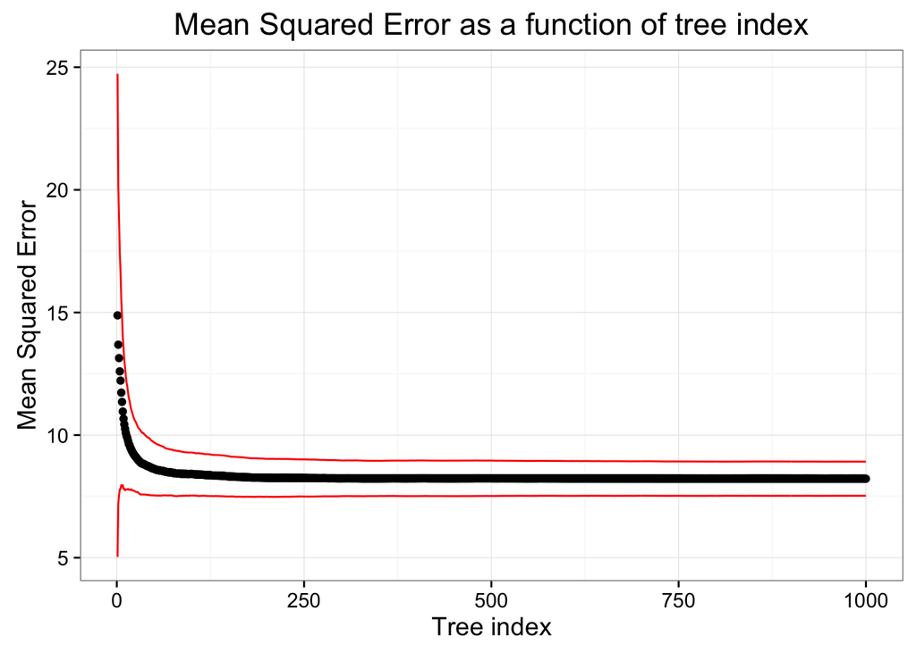

## 6.5 Computes R squared coefficient and plot predicted/measured values of whitefly survival

Compiles all r2 coefficients, one for each Random Forest model created (= N bootstraps) Important: for **original** values of whitefly survival

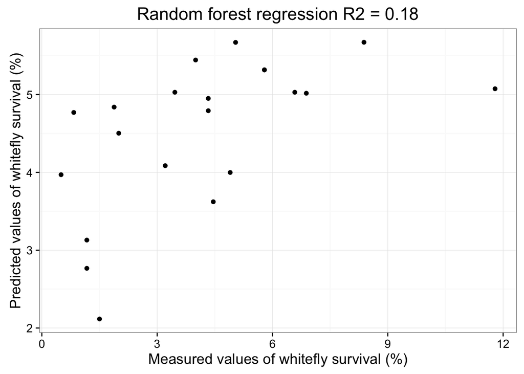

## 6.6 Plot distributions of random R2 coefficients

Important: here we use the **permutated** values for whitefly survival.

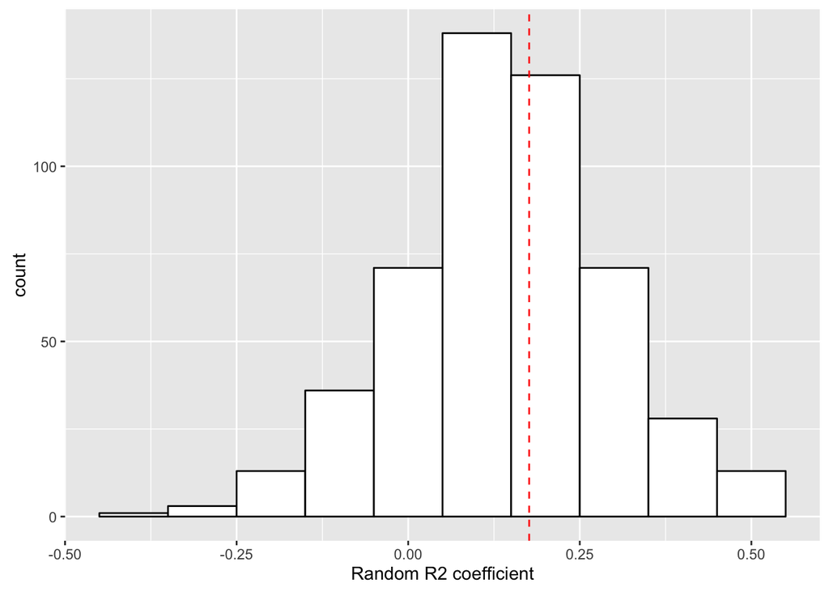

```r
# creates an empty vector of
permuted_r2 = vector(length = nboots)

# get all r2 coefficients (one for each RF model)
for (k in seq_along(1:nboots)){
  test = as.data.frame(permuted[[2]][[k]]) # permuted[[2]] = test datasets
  rf = permutedForests[[k]]
  permuted_r2[k] = rSquared(test$value,test$value - rf$test$predicted)
  }

# dataframe for plot
forplot = data.frame(index=seq(from = 1,to = nboots,by = 1),permutedR2 = permuted_r2)

# Plot permuted r2 distribution and add vertical line for non random R2
p2 = ggplot(forplot,aes(permutedR2)) +
  geom_histogram(binwidth = 0.1,colour="black",fill="white") +
  labs(x = "Random R2 coefficient") +
  geom_vline(xintercept = mean(r2),colour="red",linetype="dashed")
print(p2)
```

```r
ggsave(filename = "RandomR2distribution.png",width = 7,height = 5,dpi = 600)
```

# 7 Extract variable importance and plot

**Variable importance for regression**: %IncMSE is the mean increase in Mean Squared Error. If the increase is huge, that means that if the metabolite is important, removing it from the set of predictors should increase the error.

## 7.1 Plot ion importance as a function of MSE increase

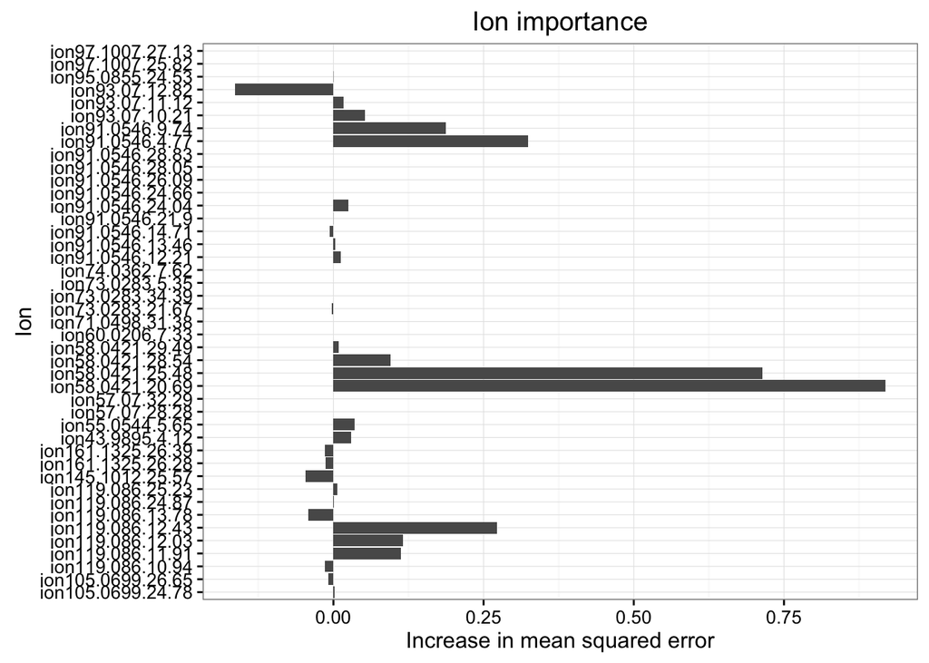

## 7.2 Final table of metabolite importance

| Ion | Increase MSE | Rank |
| --- | --- | --- |
| ion58.0421.20.69 | 0.92 | 1 |
| ion58.0421.25.48 | 0.71 | 2 |
| ion91.0546.4.77 | 0.32 | 3 |
| ion119.086.12.43 | 0.27 | 4 |
| ion91.0546.9.74 | 0.19 | 5 |
| ion119.086.12.03 | 0.12 | 6 |
| ion119.086.11.91 | 0.11 | 7 |
| ion58.0421.28.54 | 0.10 | 8 |
| ion93.07.10.21 | 0.05 | 9 |
| ion55.0544.5.65 | 0.04 | 10 |

## 7.3 Plot the abundance of the 5 top metabolites

### 7.3.1 Data preparation

1. Selecting only the interesting metabolites (top 5)
2. Add species name for plot
3. Adding the phenotype value for each accession

### 7.3.2 Plot

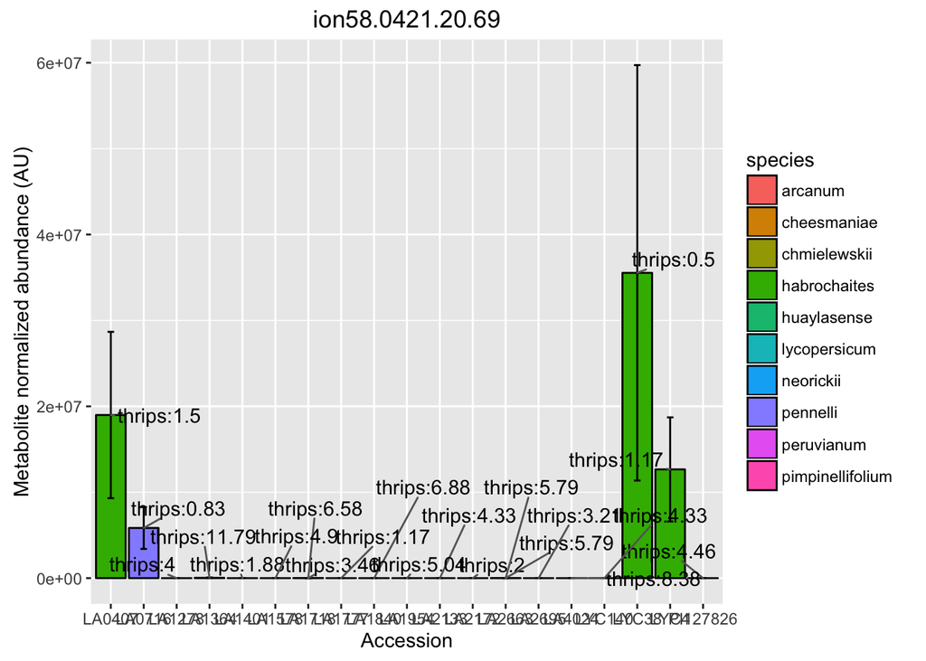

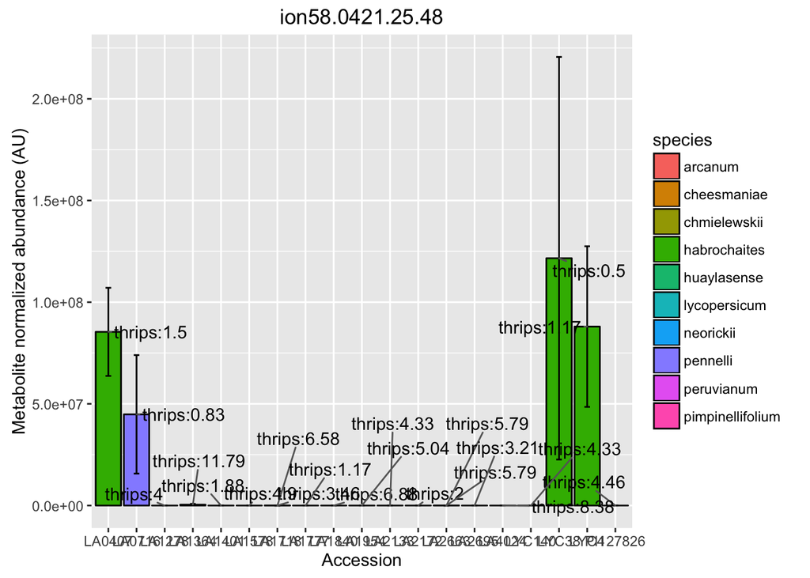

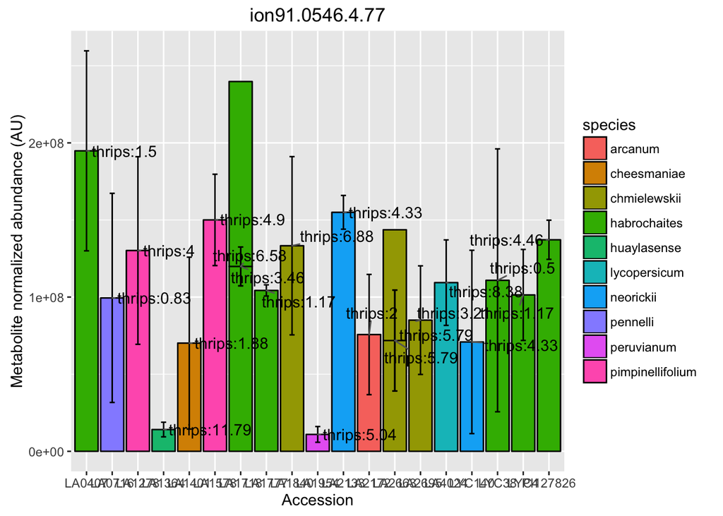

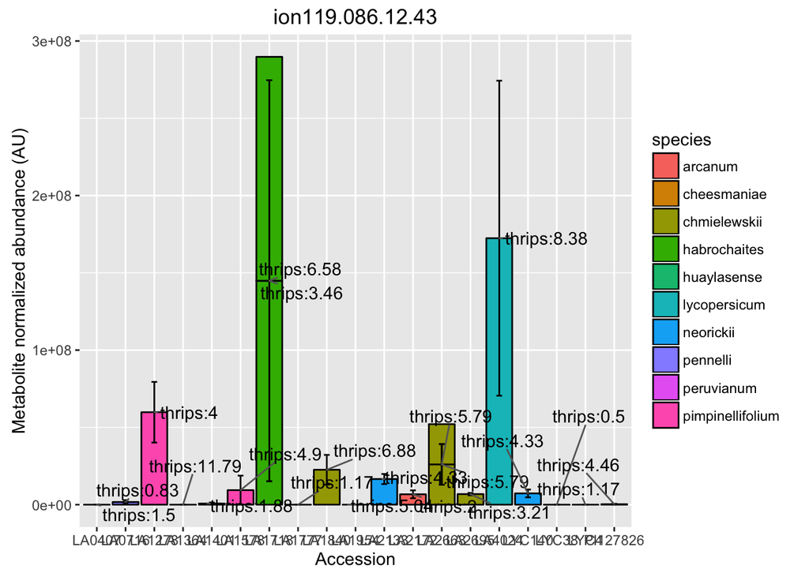

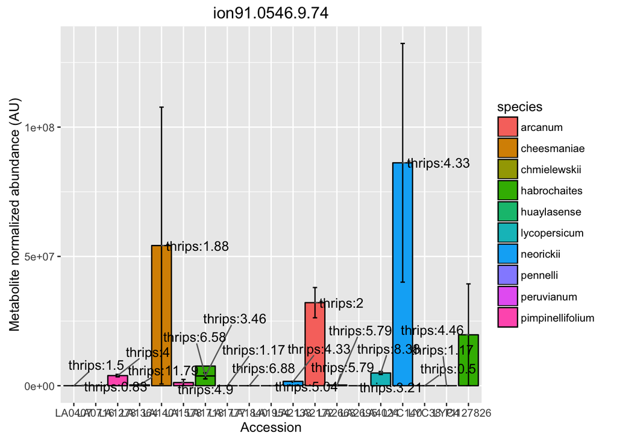

```r
# plot
for (i in seq_along(goodions)){
  tmp = dplyr::filter(ionslevels,compound == goodions[i])
  g = ggplot(tmp,aes(accession,average,fill=species)) +
    geom_bar(stat = "identity",colour="black") +
    geom_errorbar(aes(x = accession,ymin=average - se,ymax = average + se),width=0.2) +
    ggtitle(label = goodions[i]) +
    labs(x = "Accession",y = "Metabolite normalized abundance (AU)") +
    geom_text_repel(data = tmp,aes(accession,average),label = paste(config$phenotype$type,sep = ":",tmp$phenotypevalue),nudge_x = 1)
  print(g)
}
```